# Technical Trading Indicators(1)：Price

Glidis

2019-07-27

就股票交易来说，各种分析方法、套路层出不穷。进入行情界面后，除了让人印象深刻的红红绿绿柱子、数字之外，恐怕就是那些颜色不一，奇形怪状的曲线了。这些曲线其实都对应着经典的技术指标。对于有那么一点点统计学基础的选手，了解一下技术指标的含义和算法，并不是太坏的事情。这里借助R的`quantmod`和`TTR`两个包，对各色技术指标做一梳理，权当备忘。从结构上来说，本系列（指标略多，1篇文档怕只能罗列若干）文档打算从`价`和`量`两方面对指标分类，再按指标的算法和用法粗略分为`趋势`、`波动`和`趋势+波动`三组。若还能坚持写去下的话，后面不免也会对常见的基于技术指标的交易规则窥测。

为了不误导不幸中看到了本文档，且打算一试身手的大好青年，还是要念叨一下：

**股市有风险，入市需谨慎**

```r
library(quantmod)
library(TTR)
getSymbols('BILI')
```

**以下指标（Indicators）均基于价格生成**

## 1. Volatility

### ATR

True Range和Average True Range是波动(Volatility)的一种度量。

计算方法：

$TR = \max[(high - low), |high - close_{prev}|, |low - close_{prev}|]$  
或  
$TR = \max(high, close_{prev}) - \min(low, close_{prev})$  
第一次算取平均，默认的$n = 14$  
$ATR_0 = \sum_{i=1}^n(TR_i)/n$  
之后则迭代计算  
$ATR_t = [(n-1)ATR_{t-1} + TR_t]/n$

图示如下

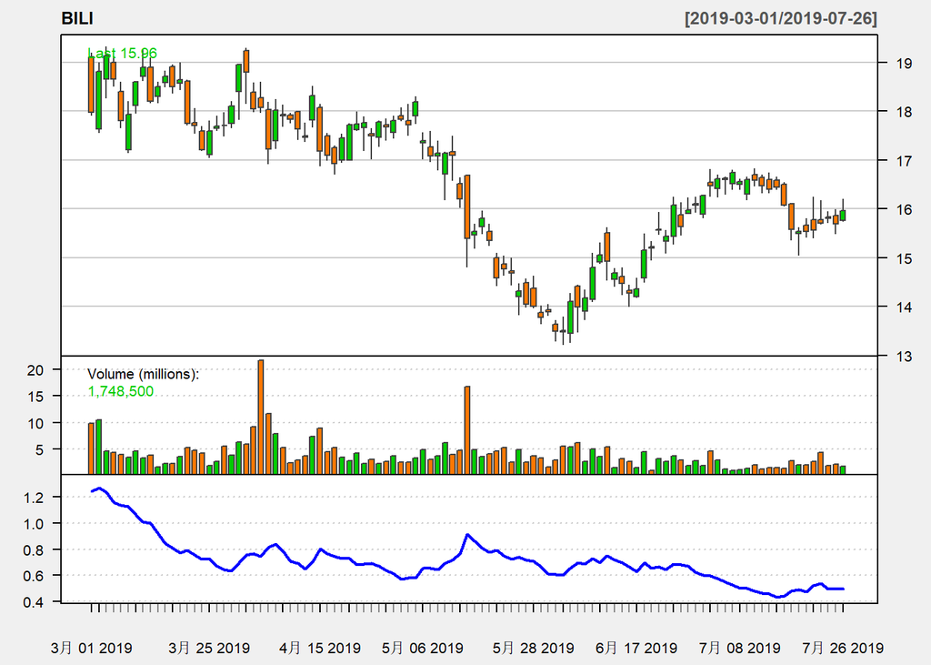

```r
bili_atr <- ATR(BILI) ## get ATR from TTR package, has nothing to do with plots below
chartSeries(BILI,
            subset='2019-03::2019-07',
            theme=chartTheme('white'),
            TA=c(addVo(),  ## Volume
                 addATR()  ## ATR
                 )
            )
```

## 2. Trend

### ADX

Welles Wilder’s Directional Movement Index，可以用来配置交易规则。由四条线组成：

- **DIp**, The positive Direction Index.
- **DIn**, The negative Direction Index.
- **DX**, The Direction Index.
- **ADX**, The Average Direction Index(trend strength).

计算方法：

1. 先计算`+DM`和`-DM`

   ```
   UpMove = today's high − yesterday's high
   DownMove = yesterday's low − today's low
   if UpMove > DownMove and UpMove > 0, then +DM = UpMove, else +DM = 0
   if DownMove > UpMove and DownMove > 0, then -DM = DownMove, else -DM = 0
   ```

2. 计算`+DI`和`-DI`，$n$默认取14(Welles Wilder)

   ```
   sum(+DM) = (n-1)*sum(+DM)_{-1} + (+DM)
   sum(-DM) = (n-1)*sum(-DM)_{-1} + (-DM)
   sum(TR) = n*ATR
   +DI = 100 * sum(+DM)/sum(TR)
   -DI = 100 * sum(-DM)/sum(TR)
   ```

3. 计算`DX`和`ADX`

   ```
   DX = [(+DI) - (-DI)]/[(+DI) + (-DI)]
   ADX = [(n-1)*ADX_{-1} + DX]/n
   ```

`DX`或`ADX`越大，趋势越强，此时`+DI`向上交叉`-DI`可视为买入信号，`-DI`向上交叉`+DI`可视为卖出信号。当然有经验的选手是一般不会选交叉作为交易信号的。

图示如下

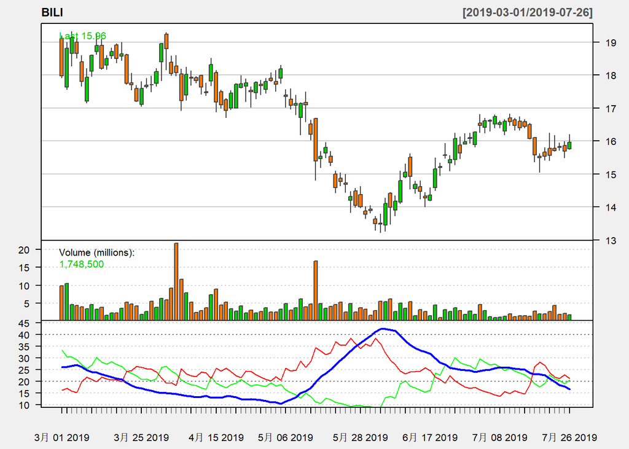

```r
bili_adx <- ADX(BILI)
chartSeries(BILI,
            subset='2019-03::2019-07',
            theme=chartTheme('white'),
            TA=c(addVo(),
                 addADX()  ## ATR
                 )
            )
```

### Aroon and Aroon Oscillator

Aroon可以用来识别趋势的起始，由上下两条线组成，度量了过去$n$期（默认取20）中，最高的High和最低的Low距现在多久。

计算方法：

$AroonUp = 100 * \frac{n-PeriodsSinceHighestHigh}{n}$

$AroonDown = 100 * \frac{n-PeriodsSinceLowestLow}{n}$

$AroonOscillator = AroonUp - AroonDown$

AroonUp(AroonDown) 在70至100间时，可认为上升（下跌）趋势；AroonUp大于70且AroonDown小于30时，可认为是强上升趋势。若不介意的话交叉点也可以略略参考一下。

图示如下

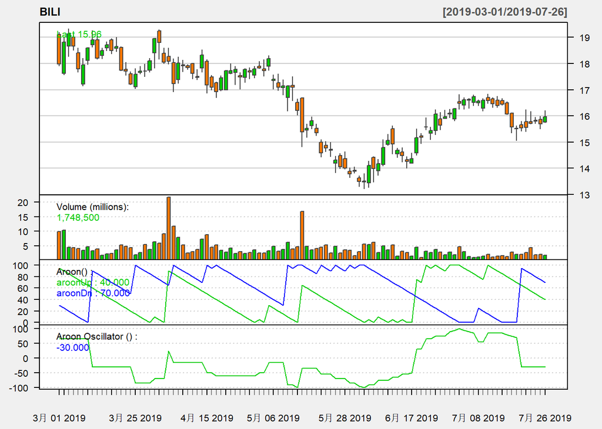

```r
bili_aroon <- aroon(BILI[, c("BILI.High", "BILI.Low")])
chartSeries(BILI,
            subset='2019-03::2019-07',
            theme=chartTheme('white'),
            TA=c(addVo(),
                 addAroon(),
                 addAroonOsc()
                 )
            )
```

## 3. Volitality + Trends

### Bollinger Bands

Bollinger Bands由三条线组成，中间是一条价格均线，上下两条边界可视为关于价格均线的置信区间。  
价格均线中的价格一般指的是初始价格（typical price），即[high+low+close]/3，用来平均的时间窗口一般是20期。如果数据中没有high、low和close，那么一般会用close等其他价格来替换。

计算方法，其中均值和标准差都是依据前$n$期数据滚动计算的，$F$默认取2：

$TP = \frac{High+Low+Close}{3}$

$mavg = \frac{1}{n}\sum_{i=1}^n TP_i$

$\sigma = \mathbf{std}(TP_i)$

$up = mavg + F*\sigma$

$dn = mavg - F*\sigma$

$pctB = (TP - dn)/(up -dn)$

$BandWidth = up - dn = 2*F*\sigma$

简单来说，BandWidth的变窄通常意味着一个趋势的即将结束，变宽则意味着一个新的趋势即将开始。up和dn虽然从形式上类似于置信区间带，但其计算过程忽略了每期价格见的相关性，并不能当做正态分布情形来推断，价格落在up和dn之间的概率并不是略大于95%，按经验来看只有80%+。个人愚见，Bollinger Bands利用了较多的信息（但未涉及交易量），有区间，有趋势，很值得琢磨一下自定义配置方案。

图示如下

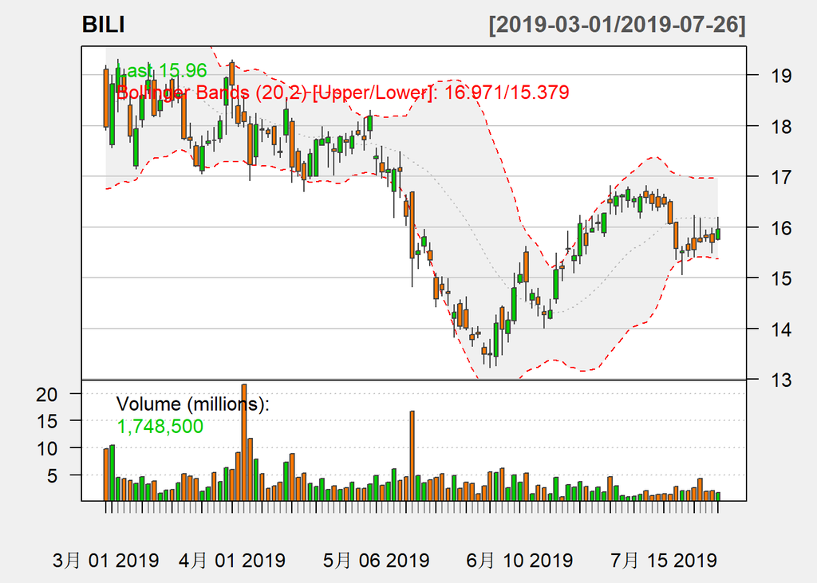

```r
bili_bbands_hlc <- BBands(BILI[, c("BILI.High", "BILI.Low", "BILI.Close")])
bili_bbands_close <- BBands(BILI[, c("BILI.Close")])
chartSeries(BILI,
            subset='2019-03::2019-07',
            theme=chartTheme('white'),
            TA=c(addVo(),
                 addBBands()
                 )
            )
```

### CCI

计算方法，其中均值和MAD都是依据前$n$期数据滚动计算的，$c$默认取0.015：

$TP = \frac{High+Low+Close}{3}$

$mavg = \frac{1}{n}\sum_{i=1}^n TP_i$

$MAD = frac{1}{n}\sum_{i=1}^n |TP_i-mavg|$

$CCI = \frac{1}{c}\frac{TP-mavg}{MAD}$

CCI一般落在-100至100之间，一个基准的交易方法：当CCI上升到（下降到）100以上（-100以下）时买进（卖出），当CCI上升到（下降到）-100以上（100以下）时买进（卖出）。

图示如下

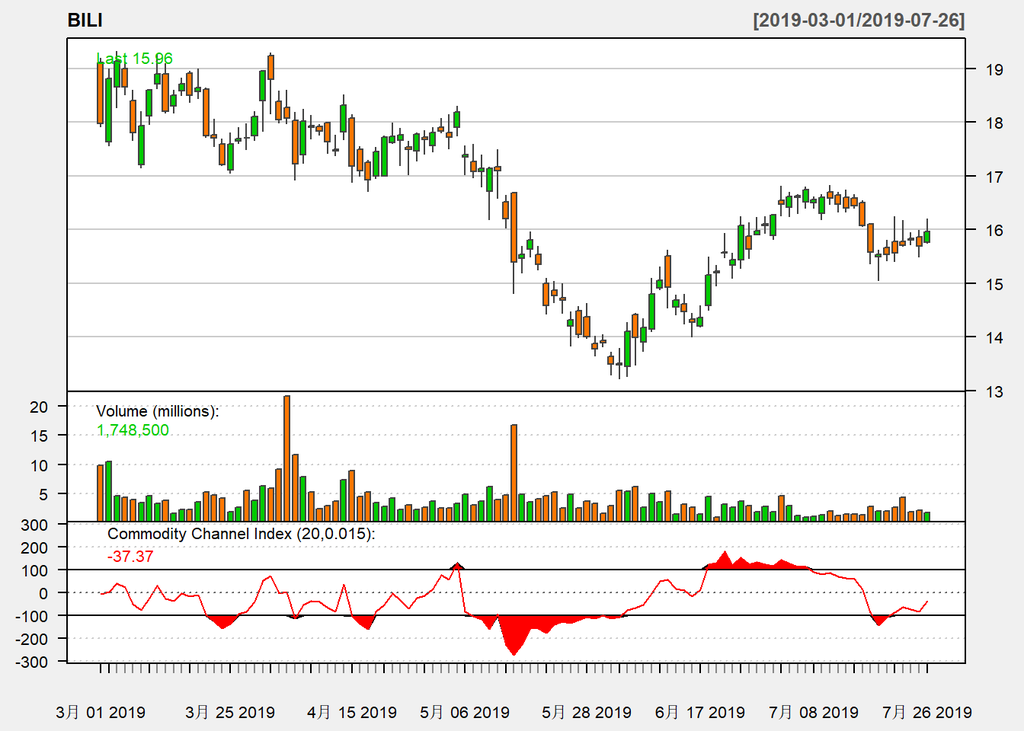

```r
bili_cci <- CCI(BILI[, c("BILI.High", "BILI.Low", "BILI.Close")])
chartSeries(BILI,
            subset='2019-03::2019-07',
            theme=chartTheme('white'),
            TA=c(addVo(),
                 addCCI()  ## ATR
                 )
            )
```